# Tarea 7 - Modelos Lineales

### autoplot

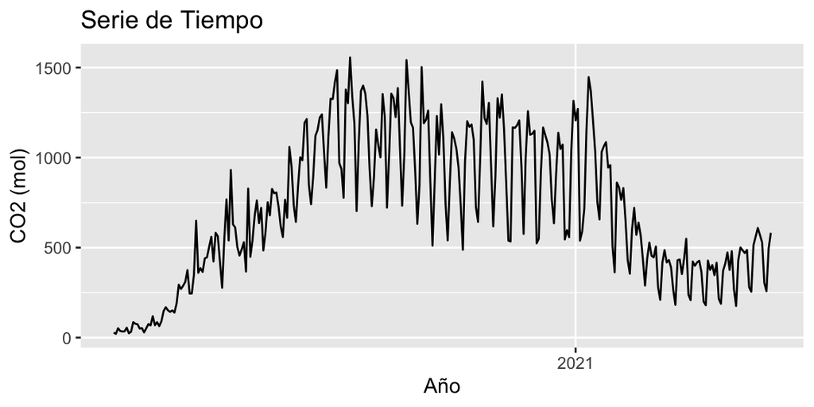

```r
autoplot(serie, xlab = "Año", ylab = "CO2 (mol)", main = "Serie de Tiempo")
```

### dygraph

```r
dygraph(aux, main = "Casos diarios de COVID", xlab = "Año", ylab = "valor", width = "100%") %>%
  dyRangeSelector(height = 20, strokeColor = "black", fillColor = "black")
```

[interactive chart not shown]

# 5. **[16 puntos]** Para este ejercicio se deben usar los datos `trafico_tren.csv`. Esta tabla cuenta con la cantidad de personas que se suben a un metro por hora. Con la tabla realice lo siguiente:

```r
datos <- read.table("../datos/trafico_tren.csv", header = T, sep = ",", dec = ".")
```

## (a) Realice un filtro para obtener los datos que se encuentran a partir del día 25 de junio del año 2016. Despliegue en el documento un `head(...)` de los resultados.

```r
library(dplyr)
#paso a formato de fechas
datos$date_time <- as.POSIXct(datos$date_time, format = "%Y-%m-%d %H:%M:%S")


datos <- datos%>%
  filter(date_time>=dmy(25062016))

head(datos)
```

|  | date_time | traffic_volume |
| --- | --- | --- |
| 1 | 2016-06-25 00:00:00 | 1869 |
| 2 | 2016-06-25 01:00:00 | 1100 |
| 3 | 2016-06-25 02:00:00 | 1005 |
| 4 | 2016-06-25 03:00:00 | 493 |
| 5 | 2016-06-25 04:00:00 | 653 |
| 6 | 2016-06-25 05:00:00 | 1009 |

## (b) Verifique si existen fechas faltantes. De ser así, impute dichas fechas y asígnele el promedio.

```r
fecha.inicio <- datos$date_time[1]
fecha.final <- datos$date_time[nrow(datos)]

total.fechas <- seq(fecha.inicio, fecha.final, by = "hour")

faltan.fechas <- total.fechas[!total.fechas %in% datos$date_time]
faltan.fechas
```

```
 [1] "2016-06-29 19:00:00 CST" "2016-07-12 09:00:00 CST"
 [3] "2016-07-12 13:00:00 CST" "2016-07-12 17:00:00 CST"
 [5] "2016-07-13 09:00:00 CST" "2016-07-13 13:00:00 CST"
 [7] "2016-07-13 17:00:00 CST" "2016-08-24 17:00:00 CST"
 [9] "2016-09-01 13:00:00 CST" "2016-09-01 14:00:00 CST"
[11] "2016-09-01 15:00:00 CST" "2016-09-18 11:00:00 CST"
[13] "2016-09-18 12:00:00 CST" "2016-09-20 09:00:00 CST"
[15] "2016-09-21 20:00:00 CST" "2016-09-25 17:00:00 CST"
[17] "2016-09-27 07:00:00 CST" "2016-10-07 15:00:00 CST"
[19] "2016-10-08 14:00:00 CST" "2016-10-09 09:00:00 CST"
[21] "2016-10-10 09:00:00 CST" "2016-10-14 09:00:00 CST"
[23] "2016-10-15 08:00:00 CST" "2016-10-15 10:00:00 CST"
[25] "2016-10-15 13:00:00 CST" "2016-10-15 20:00:00 CST"
[27] "2016-10-16 04:00:00 CST" "2016-10-16 05:00:00 CST"
[29] "2016-10-19 09:00:00 CST" "2016-10-19 12:00:00 CST"
```

[output cut: 24 more lines]

```r
datos <- union_all(datos, data.frame(date_time = faltan.fechas))

datos <- datos[order(datos$date_time), ]


## Asignamos la media

datos$traffic_volume[is.na(datos$traffic_volume)] <- mean(datos$traffic_volume, na.rm = T)

datos1 <- datos%>%
  group_by(date_time)%>%
  summarise(traffic_volume = mean(traffic_volume))
```

## (c) Convierta los datos a una serie de tiempo `ts`. Utilice una frecuencia de forma que el Patrón-Estacional sea diario (Observe que la tabla de datos viene por hora).

```r
vector.fechas <- seq(fecha.inicio, fecha.final, by = "hour")

serie <- ts(datos1$traffic_volume, frequency = 24, start = 1)


aux <- xts(serie, order.by = vector.fechas)

aux
```

```
                        [,1]
2016-06-25 00:00:00 1869.000
2016-06-25 01:00:00 1100.000
2016-06-25 02:00:00 1005.000
2016-06-25 03:00:00  493.000
2016-06-25 04:00:00  653.000
2016-06-25 05:00:00 1009.000
2016-06-25 06:00:00 1595.000
2016-06-25 07:00:00 2175.000
2016-06-25 08:00:00 2806.000
2016-06-25 09:00:00 3536.000
2016-06-25 10:00:00 3970.000
2016-06-25 11:00:00 4257.000
2016-06-25 12:00:00 4544.000
2016-06-25 13:00:00 4363.000
2016-06-25 14:00:00 4395.000
2016-06-25 15:00:00 4298.000
2016-06-25 16:00:00 4341.000
2016-06-25 17:00:00 4215.000
2016-06-25 18:00:00 3808.000
2016-06-25 19:00:00 3154.000
2016-06-25 20:00:00 2882.000
2016-06-25 21:00:00 3038.000
2016-06-25 22:00:00 3255.000
2016-06-25 23:00:00 2583.000
2016-06-26 00:00:00 1658.000
2016-06-26 01:00:00 1277.000
2016-06-26 02:00:00  718.000
2016-06-26 03:00:00  460.000
2016-06-26 04:00:00  385.000
2016-06-26 05:00:00  530.000
2016-06-26 06:00:00  926.000
2016-06-26 07:00:00 1241.000
2016-06-26 08:00:00 2078.000
2016-06-26 09:00:00 3101.000
2016-06-26 10:00:00 3956.000
2016-06-26 11:00:00 3893.000
2016-06-26 12:00:00 4303.000
2016-06-26 13:00:00 4403.000
2016-06-26 14:00:00 4241.000
```

[output cut: 22 more lines]

```
2016-06-27 13:00:00 4422.000
2016-06-27 14:00:00 4727.000
2016-06-27 15:00:00 4825.000
2016-06-27 16:00:00 5832.000
2016-06-27 17:00:00 5347.000
2016-06-27 18:00:00 3959.000
2016-06-27 19:00:00 2931.000
2016-06-27 20:00:00 2626.000
2016-06-27 21:00:00 2400.000
2016-06-27 22:00:00 1968.000
2016-06-27 23:00:00 1129.000
2016-06-28 00:00:00  567.000
2016-06-28 01:00:00  410.000
2016-06-28 02:00:00  316.000
 [ reached getOption("max.print") -- omitted 19797 rows ]
```

## (d) Muestre la serie de tiempo con un gráfico utilizando plot y autplot.

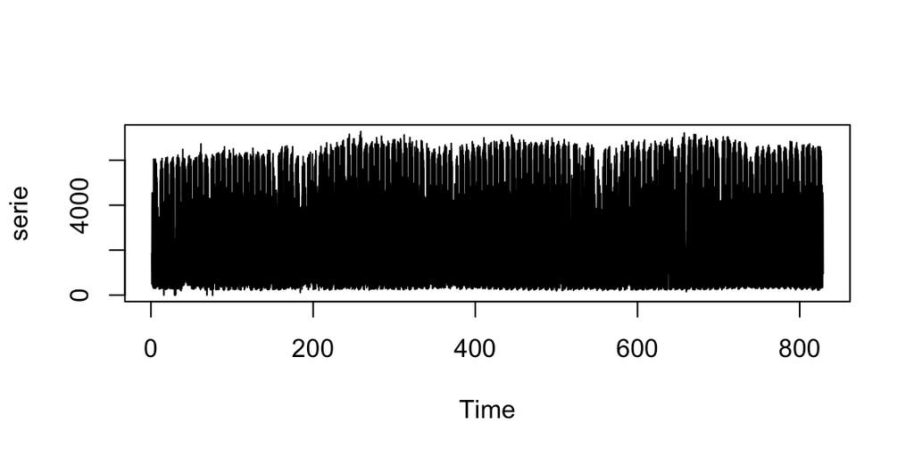

```r
plot(serie)
```

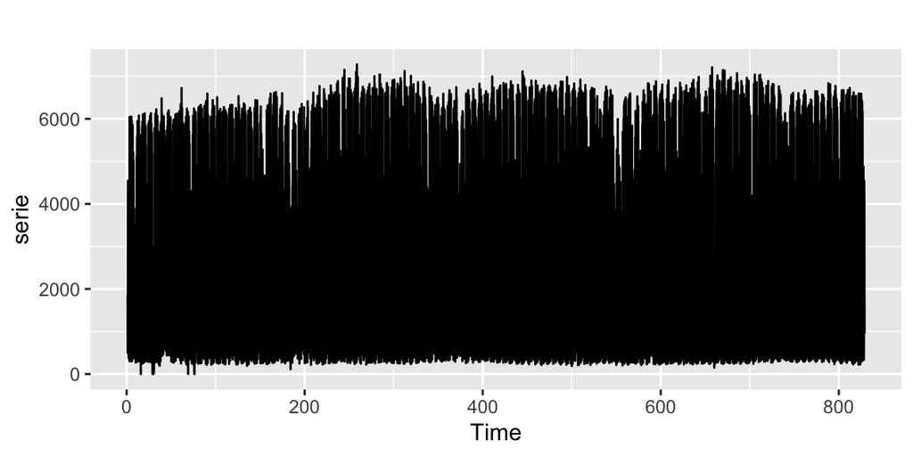

```r
autoplot(serie)
```

```r
dygraph(aux, main = "Serie de Tiempo", xlab = "Año", ylab = "valor", width = "100%") %>%
  dyOptions(fillGraph = TRUE, fillAlpha = 0.4) %>%
  dyRangeSelector(height = 20, strokeColor = "black", fillColor = "black")
```

[interactive chart not shown]

# 6. **[12 puntos]** Utilizando nuevamente los datos `trafico_tren.csv` (con el filtro aplicado en el punto anterior) y los paquetes `dplyr` y `lubridate`, realice lo siguiente:

## (a) Transforme la serie de datos por hora en una serie de datos promediados por día y convierta a serie de tiempo con Patrón-Estacional semanal. Despliegue en el documento un `head(...)` de los resultados.

```r
#promedio por día
datosDia <- datos1%>%
  group_by(date_time = round_date(date_time,"day"))%>%
  summarise(traffic_volume = mean(traffic_volume))

vector.fechas <- seq(fecha.inicio, fecha.final, by = "hour")

#Padron Estacional Semanal y los datos son diarios entonces 7 días por semana
serie <- ts(datosDia$traffic_volume, frequency = 7, start = c(1,wday(fecha.inicio)))

head(serie)
```

```
Time Series:
Start = c(1, 7)
End = c(2, 5)
Frequency = 7
[1] 2039.000 2712.458 3133.625 3329.167 3474.458 3386.327
```

```r
datosMes <- datos1%>%
  group_by(date_time = round_date(date_time,"month"))%>%
  summarise(traffic_volume = mean(traffic_volume))

#Datos mensuales y Padron estacional anual
serie <- ts(datosMes$traffic_volume, frequency = 12, start = c(2016, 7) )

head(serie)
```

```
          Jul      Aug      Sep      Oct      Nov      Dec
2016 2975.800 2994.312 3174.282 3189.777 3168.015 3090.590
```

## (c) Transforme la serie de datos por hora en una serie de datos sumados por mes y convierta a serie de tiempo con Patrón-Estacional anual. Despliegue en el documento un `head(...)` de los resultados.

```r
datosMes <- datos1%>%
  group_by(date_time = round_date(date_time,"month"))%>%
  summarise(traffic_volume = sum(traffic_volume))

#Datos mensuales y Padron estacional anual
serie <- ts(datosMes$traffic_volume, frequency = 12, start = c(2016, 7) )

head(serie)
```

```
         Jul     Aug     Sep     Oct     Nov     Dec
2016 1535513 2227768 2323574 2334917 2318987 2262312
```

# 7. **[16 puntos]** La tabla `USA_CR.csv` contiene los movimientos de compra y venta del colón con respecto al dólar desde el 15 de Enero del 2016 al 20 de Septiembre del 2019. Con la tabla realice lo siguiente:

```r
datos <- read.table("../datos/USA_CR.csv", header = T, sep = ";", dec = ",")

str(datos)
```

```
'data.frame':   953 obs. of  3 variables:
 $ FECHA             : chr  "15 ene 2016" "18 ene 2016" "19 ene 2016" "20 ene 2016" ...
 $ TIPO_CAMBIO_COMPRA: num  529 529 529 529 529 ...
 $ TIPO_CAMBIO_VENTA : num  541 541 541 542 542 ...
```

```r
#pasamos a formato fecha
datos$FECHA <- as.POSIXct(datos$FECHA, format = "%d %b %Y")
```

## (a) Encuentre las fechas faltantes si es que las hay, incluya fines de semana, e impute dichas fechas y para cada variable asígnele su promedio.

```r
fecha.inicio <- datos$FECHA[1]
fecha.final <- datos$FECHA[nrow(datos)]

total.fechas <- seq(fecha.inicio, fecha.final, by = "day")

faltan.fechas <- total.fechas[!total.fechas %in% datos$FECHA]
faltan.fechas
```

```
 [1] "2016-01-16 CST" "2016-01-17 CST" "2016-01-23 CST" "2016-01-24 CST"
 [5] "2016-01-30 CST" "2016-01-31 CST" "2016-02-06 CST" "2016-02-07 CST"
 [9] "2016-02-13 CST" "2016-02-14 CST" "2016-02-20 CST" "2016-02-21 CST"
[13] "2016-02-27 CST" "2016-02-28 CST" "2016-03-05 CST" "2016-03-06 CST"
[17] "2016-03-12 CST" "2016-03-13 CST" "2016-03-19 CST" "2016-03-20 CST"
[21] "2016-03-25 CST" "2016-03-26 CST" "2016-03-27 CST" "2016-04-02 CST"
[25] "2016-04-03 CST" "2016-04-09 CST" "2016-04-10 CST" "2016-04-16 CST"
[29] "2016-04-17 CST" "2016-04-23 CST" "2016-04-24 CST" "2016-04-30 CST"
[33] "2016-05-01 CST" "2016-05-07 CST" "2016-05-08 CST" "2016-05-14 CST"
[37] "2016-05-15 CST" "2016-05-21 CST" "2016-05-22 CST" "2016-05-28 CST"
[41] "2016-05-29 CST" "2016-06-04 CST" "2016-06-05 CST" "2016-06-11 CST"
[45] "2016-06-12 CST" "2016-06-18 CST" "2016-06-19 CST" "2016-06-25 CST"
[49] "2016-06-26 CST" "2016-07-02 CST" "2016-07-03 CST" "2016-07-09 CST"
[53] "2016-07-10 CST" "2016-07-16 CST" "2016-07-17 CST" "2016-07-23 CST"
[57] "2016-07-24 CST" "2016-07-30 CST" "2016-07-31 CST" "2016-08-06 CST"
[61] "2016-08-07 CST" "2016-08-13 CST" "2016-08-14 CST" "2016-08-20 CST"
[65] "2016-08-21 CST" "2016-08-27 CST" "2016-08-28 CST" "2016-09-03 CST"
[69] "2016-09-04 CST" "2016-09-10 CST" "2016-09-11 CST" "2016-09-17 CST"
[73] "2016-09-18 CST" "2016-09-24 CST" "2016-09-25 CST"
 [ reached 'max' / getOption("max.print") -- omitted 317 entries ]
```

```r
datos <- union_all(datos, data.frame(FECHA = faltan.fechas))

datos <- datos[order(datos$FECHA), ]


## Asignamos la media

datos$TIPO_CAMBIO_COMPRA[is.na(datos$TIPO_CAMBIO_COMPRA)] <- mean(datos$TIPO_CAMBIO_COMPRA, na.rm = T)

datos$TIPO_CAMBIO_VENTA[is.na(datos$TIPO_CAMBIO_VENTA)] <- mean(datos$TIPO_CAMBIO_VENTA, na.rm = T)
```

## (b) Elimine los días bisiestos (29 de febrero) en caso de haber alguno.

```r
datos <- datos[!(month(datos$FECHA) == 2 & day(datos$FECHA) == 29),]
```

## (c) Convierta los datos a una serie de tiempo `ts` utilizado la variable `TIPO_CAMBIO_COMPRA.csv`. Utilice una frecuencia de forma que el Patrón-Estacional sea anual.

```r
serie <- ts(datos$TIPO_CAMBIO_COMPRA, frequency = 365, start = c(2016,yday(fecha.inicio)))

serie
```

```
Time Series:
Start = c(2016, 15)
End = c(2019, 263)
Frequency = 365
 [1] 528.7400 564.4871 564.4871 528.7400 528.8100 529.0100 529.0100 529.5400
 [9] 564.4871 564.4871 529.7700 529.8900 530.0900 530.5300 531.2900 564.4871
[17] 564.4871 531.8700 531.9900 532.1900 532.2100 532.2300 564.4871 564.4871
[25] 532.0800 531.9800 531.4400 531.1900 530.2400 564.4871 564.4871 529.4100
[33] 529.4700 529.3600 529.5900 529.4500 564.4871 564.4871 529.1800 529.2800
[41] 529.1700 529.2300 529.2300 564.4871 564.4871 529.6800 529.5900 529.5800
[49] 529.3300 564.4871 564.4871 529.4300 529.5200 529.4000 529.4300 529.0700
[57] 564.4871 564.4871 529.0800 528.9900 528.9300 528.9400 528.9600 564.4871
[65] 564.4871 528.8900 528.9500 528.8600 528.7000 564.4871 564.4871 564.4871
[73] 528.7000 528.7000 528.7700
 [ reached getOption("max.print") -- omitted 1269 entries ]
```

## (d) Muestre la serie de tiempo con un gráfico utilizando `dygraph`.

```r
fechas <- seq(fecha.inicio, fecha.final, by = "days")

aux <- xts(serie, order.by = datos$FECHA)

dygraph(aux, main = "Serie de Tiempo", xlab = "Año", ylab = "valor", width = "100%") %>%
    dyOptions(fillGraph = TRUE, fillAlpha = 0.4) %>%
    dyRangeSelector(height = 20, strokeColor = "black", fillColor = "black")
```

[interactive chart not shown]

# 8. **[16 puntos]** Repita el ejercicio anterior, pero esta vez elimine los fines de semana (Sábado y Domingo). Es decir, se deben mantener solo los días laborales. Observe que sin fines de semana la frecuencia no es la misma.

```r
#elimino los fines de semana
datos <- datos[!wday(datos$FECHA) %in% c(1, 7),]

serie <- ts(datos$TIPO_CAMBIO_COMPRA, frequency = 260, start = c(2016,yday(fecha.inicio)))

aux <- xts(serie, order.by = datos$FECHA)

dygraph(aux, main = "Serie de Tiempo", xlab = "Año", ylab = "valor", width = "100%") %>%
    dyOptions(fillGraph = TRUE, fillAlpha = 0.4) %>%
    dyRangeSelector(height = 20, strokeColor = "black", fillColor = "black")
```

[interactive chart not shown]

# 9. **[12 puntos]** El siguiente código genera datos al azar, con dichos datos realice lo que se solicita a continuación:

```r
monto <- sample(10000:20000, 1672, replace = T)
```

## (a) Suponiendo que los datos son diarios y tienen un Patrón-Estacional anual defina una serie de tiempo cuyo primer dato es el 21 de abril del año 2000.

```r
serie <- ts(monto, frequency = 365, start = c(2000,yday(ymd(20000421))))

head(serie)
```

```
Time Series:
Start = c(2000, 112)
End = c(2000, 117)
Frequency = 365
[1] 18088 14443 13696 19055 16875 19037
```

## (b) Suponiendo que los datos son por hora y tienen un Patrón-Estacional anual defina una serie de tiempo cuyo primer dato es el 11 de marzo del año 2000 a las 11pm (23 horas).

```r
vector.fechas <- seq(as.POSIXct("2000-01-01 00:00:00"), as.POSIXct("2000-03-11 23:00:00"), by = "hour")
length(vector.fechas)
```

```
[1] 1704
```

```r
serie <- ts(monto, frequency = 8760 , start = c(2000, 1704))

head(serie)
```

```
Time Series:
Start = c(2000, 1704)
End = c(2000, 1709)
Frequency = 8760
[1] 18088 14443 13696 19055 16875 19037
```

## (c) Suponiendo que los datos son por minuto y tienen un Patrón-Estacional anual defina una serie de tiempo cuyo primer dato es el 2 de enero del año 2000 a las 11:22pm.

```r
serie <- ts(monto, frequency = 525600, start = c(2000, 2843))

#minutos hasta 2 de enero - 22 minutos que ya pasaron
(yday(ymd(20000102))*1440) - 38
```

```
[1] 2842
```

```r
vector.fechas <- seq(as.POSIXct("2000-01-01 00:00:00"), as.POSIXct("2000-01-02 23:22:00"), by = "min")
length(vector.fechas)
```

```
[1] 2843
```

```r
head(serie)
```

```
Time Series:
Start = c(2000, 2843)
End = c(2000, 2848)
Frequency = 525600
[1] 18088 14443 13696 19055 16875 19037
```

## d) Suponiendo que los datos son por minuto y tienen un Patrón-Estacional anual defina una serie de tiempo cuyo primer dato es el 4 de enero del año 2000 a las 11:30pm.

```r
vector.fechas <- seq(as.POSIXct("2000-01-01 00:00:00"), as.POSIXct("2000-01-04 23:30:00"), by = "min")

length(vector.fechas)
```

```
[1] 5731
```

```r
serie <- ts(monto, frequency = 525600, start = c(2000,length(vector.fechas)))

head(serie)
```

```
Time Series:
Start = c(2000, 5731)
End = c(2000, 5736)
Frequency = 525600
[1] 18088 14443 13696 19055 16875 19037
```